# Regularization on Mice Protein Expression Data Set

Insofe Labs

28 June 2017

# Data Description

[output not shown]

```r
# Attribute Information:
#
# 1 Mouse ID
# 2-78 Values of expression levels of 77 proteins; the names of proteins
# 79 Genotype: control (c) or trisomy (t)
# 80 Treatment type: memantine (m) or saline (s)
# 81 Behavior: context-shock (CS) or shock-context (SC)
# # 82 Class: c-CS-s, c-CS-m, c-SC-s, c-SC-m, t-CS-s, t-CS-m, t-SC-s, t-SC-m
# Classes:
# c-CS-s: control mice, stimulated to learn, injected with saline (9 mice)
# c-CS-m: control mice, stimulated to learn, injected with memantine (10 mice)
# c-SC-s: control mice, not stimulated to learn, injected with saline (9 mice)
# c-SC-m: control mice, not stimulated to learn, injected with memantine (10 mice)
# t-CS-s: trisomy mice, stimulated to learn, injected with saline (7 mice)
# t-CS-m: trisomy mice, stimulated to learn, injected with memantine (9 mice)
# t-SC-s: trisomy mice, not stimulated to learn, injected with saline (9 mice)
# t-SC-m: trisomy mice, not stimulated to learn, injected with memantine (9 mice)
```

# Clean Your Global Environment

- Note that clearing the environment is a good practice while learning but when sharing the code remember to remove it.

```r
rm(list=ls(all=TRUE))
```

# Libraries Required

- Keeping the libraris at one place is a best practice
- Think and get the libraries required for the problem

```r
library(glmnet)
library(caret)
library(MASS)
library(vegan)
library(data.table)
library(doParallel)
library(DMwR)
library(dummies)
```

# Reading the Data Set

- Note that it is not always needed to get the directory set
- Just copy your csv and paste it between the quotes " " and deleted file:///

```r
data<-read.csv("D:/Academic Stuff/Regularization/Data_Cortex_Nuclear.csv",header=TRUE,sep=",",na.strings=c(" ",""))
```

## Structure Check

- Observing the structure will reveal what are the data types of attributes
- It can be helpful to understand any data type changes are required

```r
str(data)
```

```
'data.frame':   1080 obs. of  82 variables:
 $ MouseID        : Factor w/ 1080 levels "18899_1","18899_10",..: 46 53 54 55 56 57 58 59 60 47 ...
 $ DYRK1A_N       : num  0.504 0.515 0.509 0.442 0.435 ...
 $ ITSN1_N        : num  0.747 0.689 0.73 0.617 0.617 ...
 $ BDNF_N         : num  0.43 0.412 0.418 0.359 0.359 ...
 $ NR1_N          : num  2.82 2.79 2.69 2.47 2.37 ...
 $ NR2A_N         : num  5.99 5.69 5.62 4.98 4.72 ...
 $ pAKT_N         : num  0.219 0.212 0.209 0.223 0.213 ...
 $ pBRAF_N        : num  0.178 0.173 0.176 0.176 0.174 ...
 $ pCAMKII_N      : num  2.37 2.29 2.28 2.15 2.13 ...
 $ pCREB_N        : num  0.232 0.227 0.23 0.207 0.192 ...
 $ pELK_N         : num  1.75 1.6 1.56 1.6 1.5 ...
 $ pERK_N         : num  0.688 0.695 0.677 0.583 0.551 ...
 $ pJNK_N         : num  0.306 0.299 0.291 0.297 0.287 ...
 $ PKCA_N         : num  0.403 0.386 0.381 0.377 0.364 ...
```

[output cut: 68 more lines]

## Summary Check

- check the summary and remove unnecessary variables
- It is necessary to see basic stats of the variables
- NA values,Classes in the target and other attributes are counted in Summary

```r
summary(data)
```

```
     MouseID        DYRK1A_N
 18899_1 :   1   Min.   :0.1453
 18899_10:   1   1st Qu.:0.2881
 18899_11:   1   Median :0.3664
 18899_12:   1   Mean   :0.4258
 18899_13:   1   3rd Qu.:0.4877
 18899_14:   1   Max.   :2.5164
 (Other) :1074   NA's   :3
    ITSN1_N           BDNF_N
 Min.   :0.2454   Min.   :0.1152
 1st Qu.:0.4734   1st Qu.:0.2874
 Median :0.5658   Median :0.3166
 Mean   :0.6171   Mean   :0.3191
 3rd Qu.:0.6980   3rd Qu.:0.3482
 Max.   :2.6027   Max.   :0.4972
 NA's   :3        NA's   :3
     NR1_N           NR2A_N
 Min.   :1.331   Min.   :1.738
 1st Qu.:2.057   1st Qu.:3.156
 Median :2.297   Median :3.761
 Mean   :2.297   Mean   :3.844
 3rd Qu.:2.528   3rd Qu.:4.440
 Max.   :3.758   Max.   :8.483
 NA's   :3       NA's   :3
     pAKT_N
 Min.   :0.06324
 1st Qu.:0.20575
 Median :0.23118
 Mean   :0.23317
 3rd Qu.:0.25726
 Max.   :0.53905
 NA's   :3
    pBRAF_N          pCAMKII_N
 Min.   :0.06404   Min.   :1.344
 1st Qu.:0.16459   1st Qu.:2.480
 Median :0.18230   Median :3.327
 Mean   :0.18185   Mean   :3.537
 3rd Qu.:0.19742   3rd Qu.:4.482
 Max.   :0.31707   Max.   :7.464
 NA's   :3         NA's   :3
```

[output cut: 305 more lines]

```
 Control:570   Memantine:570
 Ts65Dn :510   Saline   :510





 Behavior      class
 C/S:525   c-CS-m :150
 S/C:555   c-SC-m :150
           c-SC-s :140
           c-CS-s :135
           t-SC-m :135
           t-SC-s :135
           (Other):235
```

```r
data$MouseID<-NULL
```

## Check Missing Values

- Missing values impact the learning

```r
sum(is.na(data))
```

```
[1] 1396
```

*What is the percentage of the NA values ?

```r
na.percentage=(sum(is.na(data))/(nrow(data)*ncol(data)))*100
```

*Impute the NA values using a suitable technique

```r
data<-centralImputation(data)
data$MouseID<-NULL
```

*Check for the summary

```r
summary(data)
```

```
    DYRK1A_N         ITSN1_N
 Min.   :0.1453   Min.   :0.2454
 1st Qu.:0.2882   1st Qu.:0.4737
 Median :0.3664   Median :0.5658
 Mean   :0.4256   Mean   :0.6170
 3rd Qu.:0.4876   3rd Qu.:0.6975
 Max.   :2.5164   Max.   :2.6027

     BDNF_N           NR1_N
 Min.   :0.1152   Min.   :1.331
 1st Qu.:0.2877   1st Qu.:2.059
 Median :0.3166   Median :2.297
 Mean   :0.3191   Mean   :2.297
 3rd Qu.:0.3480   3rd Qu.:2.528
 Max.   :0.4972   Max.   :3.758

     NR2A_N          pAKT_N
 Min.   :1.738   Min.   :0.06324
 1st Qu.:3.160   1st Qu.:0.20582
 Median :3.761   Median :0.23118
 Mean   :3.844   Mean   :0.23316
 3rd Qu.:4.425   3rd Qu.:0.25722
 Max.   :8.483   Max.   :0.53905

    pBRAF_N          pCAMKII_N
 Min.   :0.06404   Min.   :1.344
 1st Qu.:0.16462   1st Qu.:2.480
 Median :0.18230   Median :3.327
 Mean   :0.18185   Mean   :3.537
 3rd Qu.:0.19723   3rd Qu.:4.481
 Max.   :0.31707   Max.   :7.464

    pCREB_N           pELK_N
 Min.   :0.1128   Min.   :0.429
 1st Qu.:0.1908   1st Qu.:1.206
 Median :0.2106   Median :1.356
 Mean   :0.2126   Mean   :1.428
 3rd Qu.:0.2346   3rd Qu.:1.561
 Max.   :0.3062   Max.   :6.113

```

[output cut: 297 more lines]

```
 Control:570   Memantine:570
 Ts65Dn :510   Saline   :510





 Behavior      class
 C/S:525   c-CS-m :150
 S/C:555   c-SC-m :150
           c-SC-s :140
           c-CS-s :135
           t-SC-m :135
           t-SC-s :135
           (Other):235
```

# Target levels Distribution

```r
 table(data$class)
```

```
c-CS-m c-CS-s c-SC-m c-SC-s t-CS-m
   150    135    150    140    130
t-CS-s t-SC-m t-SC-s
   105    135    135
```

# Splitting the data

- Split the data into train data set and test data set
- Split ratio can be 80/20 or 70/30
- Splitting in case of classification be careful to see that the levels of target distribution is in same proportion in both train and test
- This can be achieved with the Caret Package “createDataPartition”

```r
rows=createDataPartition(data$class,p = 0.7,list = FALSE)
train=data[rows,]
test=data[-rows,]
```

# Testing the Class Distribution Later

```r
table(train$class)
```

```
c-CS-m c-CS-s c-SC-m c-SC-s t-CS-m
   105     95    105     98     91
t-CS-s t-SC-m t-SC-s
    74     95     95
```

```r
levels(train$class)
```

```
[1] "c-CS-m" "c-CS-s" "c-SC-m"
[4] "c-SC-s" "t-CS-m" "t-CS-s"
[7] "t-SC-m" "t-SC-s"
```

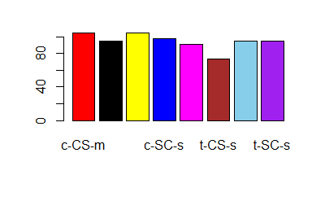

```r
plot(train$class,col=c("red","black","yellow","blue","magenta","brown","skyblue","purple"))
```

```r
table(test$class)
```

```
c-CS-m c-CS-s c-SC-m c-SC-s t-CS-m
    45     40     45     42     39
t-CS-s t-SC-m t-SC-s
    31     40     40
```

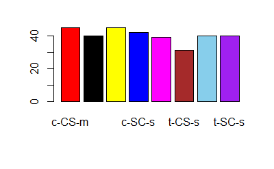

```r
plot(test$class,col=c("red","black","yellow","blue","magenta","brown","skyblue","purple"))
```

# Standardization

*Standardization is needed beacause the higher values of the attibute should not dominate the model.

```r
preProc=preProcess(data)
train=predict(preProc,train)
test=predict(preProc,test)
```

# Parallel

- Use the registerDoParallel() to speed up your process while cross validating
- Those who use linux doMC also helps the same way by creating multiple cores

```r
registerDoParallel(8)
```

# Lasso Model

- Lasso always fits a linear model
- It involves penalizing the absolute size of the regression coefficients.
- For regularization glmnet package is used.
- This package is used for both regression and classification
- Linear,Poisson regressions ,binomial and multinomial classifications are possible
- Check the help with ?glmnet and use the arguments needed

```r
x=model.matrix(train$class~.,train)
model=glmnet(x,train$class,family = "multinomial",type.multinomial = "grouped")
```

```
from glmnet Fortran code (error code -56); Convergence for 56th lambda value not reached after maxit=100000 iterations; solutions for larger lambdas returned
```

## Plots for Different Lambda

- Plot the model for different lambda values as modelled above
- The plot justifies that for different values of lambda there are different attributes which are moving towards zero.
- But the question is What is the optimum value for lambda??

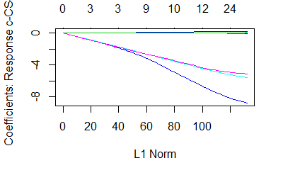

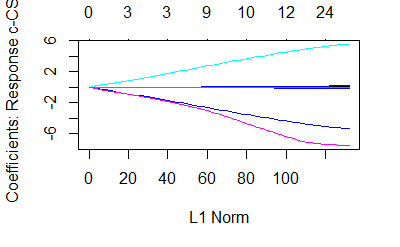

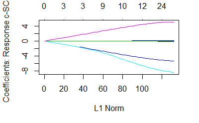

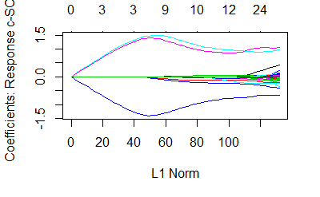

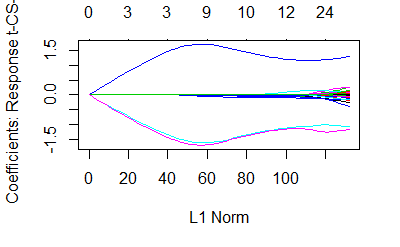

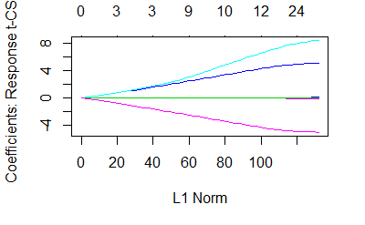

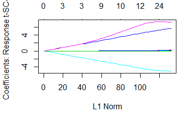

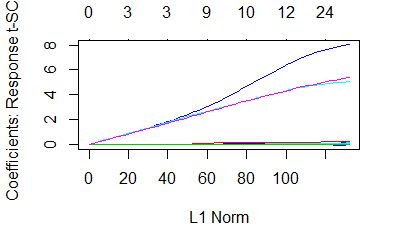

```r
plot(model)
```

## Cross Validation for Lasso

```r
cv.model<-cv.glmnet(x,train$class,type.measure="class",grouped=TRUE,parallel=TRUE,nfolds=5,family="multinomial")
```

## Predicting the Min Lambda

- plot the Cross validated model to choose the minimum lambda

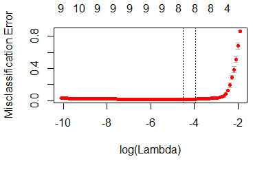

```r
plot(cv.model)
```

```r
cv.model$lambda.min
```

```
[1] 0.01097173
```

Perform the model with the lambda min choosen

```r
newmodel=glmnet(x,train$class,family = "multinomial",type.multinomial = "grouped",lambda = cv.model$lambda.min)
```

## Getting the Coefficnets for Lasso

- code to get the coefficients that are not zero from the Lasso model

```r
coef=coef(newmodel,s = cv.model$lambda.min)
 ind <- which(coef(newmodel,s = cv.model$lambda.min)[[1]] != 0)
 df_lass0 <- data.frame(
        feature=rownames(coef(newmodel, s=cv.model$lambda.min)[[1]])[ind],
        coeficient=(coef(newmodel, s=cv.model$lambda.min)[[1]])[ind])
 df_lass0
```

| feature | coeficient |
| --- | --- |
| (Intercept) | 6.513996e+00 |
| AKT_N | 1.750918e-02 |
| pNUMB_N | 1.319207e-01 |
| pP70S6_N | -4.389094e-03 |
| pPKCG_N | -1.514061e-02 |
| ARC_N | 2.842289e-06 |
| Ubiquitin_N | -7.766523e-03 |
| BAD_N | 3.651207e-03 |
| pS6_N | 7.334197e-04 |
| GenotypeTs65Dn | -6.233768e+00 |

[output cut: 2 more lines]

# Prediction on Lasso

- Convert the test data set into required format as done prior to the model

```r
xx=model.matrix(test$class~.,test)
pred<-predict(newmodel,xx,type = "class")
```

Form the table of the confusion matrix

```r
table(pred,test$class)
```

```
pred     c-CS-m c-CS-s c-SC-m
  c-CS-m     45      0      0
  c-CS-s      0     40      0
  c-SC-m      0      0     45
  c-SC-s      0      0      0
  t-CS-m      0      0      0
  t-CS-s      0      0      0
  t-SC-m      0      0      0
  t-SC-s      0      0      0

pred     c-SC-s t-CS-m t-CS-s
  c-CS-m      0      0      0
  c-CS-s      0      0      0
  c-SC-m      0      0      0
  c-SC-s     39      3      0
  t-CS-m      3     36      0
  t-CS-s      0      0     31
  t-SC-m      0      0      0
  t-SC-s      0      0      0

pred     t-SC-m t-SC-s
  c-CS-m      0      0
  c-CS-s      0      0
  c-SC-m      0      0
  c-SC-s      0      0
  t-CS-m      0      0
  t-CS-s      0      0
  t-SC-m     40      0
  t-SC-s      0     40
```

## Confusion Matrix

Use the confusion matrix and study the various metrics

```r
confusionMatrix(pred,test$class)
```

```
Confusion Matrix and Statistics

          Reference
Prediction c-CS-m c-CS-s c-SC-m
    c-CS-m     45      0      0
    c-CS-s      0     40      0
    c-SC-m      0      0     45
    c-SC-s      0      0      0
    t-CS-m      0      0      0
    t-CS-s      0      0      0
    t-SC-m      0      0      0
    t-SC-s      0      0      0
          Reference
Prediction c-SC-s t-CS-m t-CS-s
    c-CS-m      0      0      0
    c-CS-s      0      0      0
    c-SC-m      0      0      0
    c-SC-s     39      3      0
    t-CS-m      3     36      0
    t-CS-s      0      0     31
    t-SC-m      0      0      0
    t-SC-s      0      0      0
          Reference
Prediction t-SC-m t-SC-s
    c-CS-m      0      0
    c-CS-s      0      0
    c-SC-m      0      0
    c-SC-s      0      0
    t-CS-m      0      0
    t-CS-s      0      0
    t-SC-m     40      0
    t-SC-s      0     40

Overall Statistics

               Accuracy :
                 95% CI :
    No Information Rate :
    P-Value [Acc > NIR] :

```

[output cut: 70 more lines]

```
Pos Pred Value              1.0000
Neg Pred Value              1.0000
Prevalence                  0.1242
Detection Rate              0.1242
Detection Prevalence        0.1242
Balanced Accuracy           1.0000
                     Class: t-SC-s
Sensitivity                 1.0000
Specificity                 1.0000
Pos Pred Value              1.0000
Neg Pred Value              1.0000
Prevalence                  0.1242
Detection Rate              0.1242
Detection Prevalence        0.1242
Balanced Accuracy           1.0000
```

# Ridge Regression

- Ridge Regression fits a linear equation but with all the features involved
- The features that are not removed by lasso will hava a very least coeffients
- alpha =0 gives the ridge regression
- Ridge can be possible in MASS package using lm.ridge

```r
ridge=glmnet(x,train$class,family = "multinomial",type.multinomial = "grouped",alpha = 0)
```

## Cross Validated Model

```r
cv.ridge<-cv.glmnet(x,train$class,type.measure="class",grouped=TRUE,parallel=TRUE,nfolds=5,family="multinomial",alpha=0)
```

Run the model taking the lambda min

```r
new_ridge=glmnet(x,train$class,family = "multinomial",type.multinomial = "grouped",alpha = 0,lambda =cv.ridge$lambda.min )
```

## Ridge Coefficeints

```r
coef_ridge=coef(new_ridge,s = cv.ridge$lambda.min)
 ind <- which(coef(new_ridge,s = cv.ridge$lambda.min)[[1]] != 0)
 df_ridge <- data.frame(
        feature=rownames(coef(new_ridge, s=cv.ridge$lambda.min)[[1]])[ind],
        coeficient=(coef(new_ridge, s=cv.ridge$lambda.min)[[1]])[ind])
 df_ridge
```

| feature | coeficient |
| --- | --- |
| (Intercept) | 2.168577089 |
| DYRK1A_N | -0.017512162 |
| ITSN1_N | -0.095678969 |
| BDNF_N | 0.053816092 |
| NR1_N | 0.027100875 |
| NR2A_N | 0.156722442 |
| pAKT_N | 0.028545346 |
| pBRAF_N | 0.053735391 |
| pCAMKII_N | -0.237127788 |
| pCREB_N | -0.281687430 |

[output cut: 71 more lines]

# Prediction on Ridge Regularization

Predict the class for the test set

```r
pred_ridge<-predict(new_ridge,xx,type = "class")
confusionMatrix(pred_ridge,test$class)
```

```
Confusion Matrix and Statistics

          Reference
Prediction c-CS-m c-CS-s c-SC-m
    c-CS-m     45      0      0
    c-CS-s      0     40      0
    c-SC-m      0      0     45
    c-SC-s      0      0      0
    t-CS-m      0      0      0
    t-CS-s      0      0      0
    t-SC-m      0      0      0
    t-SC-s      0      0      0
          Reference
Prediction c-SC-s t-CS-m t-CS-s
    c-CS-m      0      0      0
    c-CS-s      0      0      0
    c-SC-m      0      0      0
    c-SC-s     39      3      0
    t-CS-m      3     36      0
    t-CS-s      0      0     31
    t-SC-m      0      0      0
    t-SC-s      0      0      0
          Reference
Prediction t-SC-m t-SC-s
    c-CS-m      0      0
    c-CS-s      0      0
    c-SC-m      0      0
    c-SC-s      0      0
    t-CS-m      0      0
    t-CS-s      0      0
    t-SC-m     40      0
    t-SC-s      0     40

Overall Statistics

               Accuracy :
                 95% CI :
    No Information Rate :
    P-Value [Acc > NIR] :

```

[output cut: 70 more lines]

```
Pos Pred Value              1.0000
Neg Pred Value              1.0000
Prevalence                  0.1242
Detection Rate              0.1242
Detection Prevalence        0.1242
Balanced Accuracy           1.0000
                     Class: t-SC-s
Sensitivity                 1.0000
Specificity                 1.0000
Pos Pred Value              1.0000
Neg Pred Value              1.0000
Prevalence                  0.1242
Detection Rate              0.1242
Detection Prevalence        0.1242
Balanced Accuracy           1.0000
```

# Elastic Net Regularization

```r
elastic=glmnet(x,train$class,family = "multinomial",type.multinomial = "grouped",alpha = 0.5)
```

## Cross Validated Model

Cross validated model for lambda min

```r
cv.elastic<-cv.glmnet(x,train$class,type.measure="class",grouped=TRUE,parallel=TRUE,nfolds=5,family="multinomial",alpha=0.5)
```

Re Run the model with lambda min

```r
new_elastic=glmnet(x,train$class,family = "multinomial",type.multinomial = "grouped",alpha = 0,lambda =cv.elastic$lambda.min )
```

## Getting the Elastic Net attributes

```r
coef_elastic=coef(new_elastic,s = cv.elastic$lambda.min)
 ind <- which(coef(new_elastic,s = cv.elastic$lambda.min)[[1]] != 0)
 df_elastic <- data.frame(
        feature=rownames(coef(new_elastic, s=cv.elastic$lambda.min)[[1]])[ind],
        coeficient=(coef(new_elastic, s=cv.elastic$lambda.min)[[1]])[ind])
 df_elastic
```

| feature | coeficient |
| --- | --- |
| (Intercept) | 2.679898491 |
| DYRK1A_N | -0.032024723 |
| ITSN1_N | -0.139367171 |
| BDNF_N | 0.062153510 |
| NR1_N | 0.034348749 |
| NR2A_N | 0.197478380 |
| pAKT_N | 0.040984019 |
| pBRAF_N | 0.083101540 |
| pCAMKII_N | -0.310185752 |
| pCREB_N | -0.348478570 |

[output cut: 71 more lines]

# Prediction on Elastic Net Regression

```r
pred_elastic<-predict(new_elastic,xx,type = "class")
confusionMatrix(pred_elastic,test$class)
```

```
Confusion Matrix and Statistics

          Reference
Prediction c-CS-m c-CS-s c-SC-m
    c-CS-m     45      0      0
    c-CS-s      0     40      0
    c-SC-m      0      0     45
    c-SC-s      0      0      0
    t-CS-m      0      0      0
    t-CS-s      0      0      0
    t-SC-m      0      0      0
    t-SC-s      0      0      0
          Reference
Prediction c-SC-s t-CS-m t-CS-s
    c-CS-m      0      0      0
    c-CS-s      0      0      0
    c-SC-m      0      0      0
    c-SC-s     39      3      0
    t-CS-m      3     36      0
    t-CS-s      0      0     31
    t-SC-m      0      0      0
    t-SC-s      0      0      0
          Reference
Prediction t-SC-m t-SC-s
    c-CS-m      0      0
    c-CS-s      0      0
    c-SC-m      0      0
    c-SC-s      0      0
    t-CS-m      0      0
    t-CS-s      0      0
    t-SC-m     40      0
    t-SC-s      0     40

Overall Statistics

               Accuracy :
                 95% CI :
    No Information Rate :
    P-Value [Acc > NIR] :

```

[output cut: 70 more lines]

```
Pos Pred Value              1.0000
Neg Pred Value              1.0000
Prevalence                  0.1242
Detection Rate              0.1242
Detection Prevalence        0.1242
Balanced Accuracy           1.0000
                     Class: t-SC-s
Sensitivity                 1.0000
Specificity                 1.0000
Pos Pred Value              1.0000
Neg Pred Value              1.0000
Prevalence                  0.1242
Detection Rate              0.1242
Detection Prevalence        0.1242
Balanced Accuracy           1.0000
```

# Try for Various alpha all the best!(NOT GRADED)

For various values of alpha try the models and compare the accuracies (Try it not graded )